# Objective

The objective of this project is to develop a machine learning model for classifying clients based on their credit risk. By leveraging a dataset containing key financial and demographic attributes, the model aims to distinguish between low-risk (0) and high-risk (1) clients. This classification will assist financial institutions in making informed lending decisions, reducing default rates, and optimizing risk management strategies.

# Solution

The credit risk classification project follows a structured machine learning pipeline, incorporating data preprocessing (LE, OHE), handling of imbalances (KNN, SMOTE), and model training with robust classifiers (RFC, CBC) to ensure high predictive performance and business applicability. Below there are steps undertaken.

```python
import pandas as pd
import matplotlib.pyplot as plt
import numpy as np
import seaborn as sns
import scipy.stats as stats
from scipy.stats import shapiro, normaltest
from sklearn.model_selection import train_test_split
from sklearn.ensemble import RandomForestClassifier
from sklearn.metrics import confusion_matrix, classification_report, roc_auc_score, accuracy_score
from sklearn.impute import KNNImputer
from imblearn.over_sampling import SMOTE
from sklearn.preprocessing import StandardScaler
from catboost import CatBoostClassifier
import shap
```

## 1. Data overiew

The data is collected and saved as a CSV file, so we will import it with the pandas library.

```python
data = pd.read_csv("/Users/petromelnyk/Desktop/projects/bank_proj/bank_data.csv", index_col = 0)
data.head()
```

|  | age | income | children | credit_history | overdue_payments | active_loans | years_in_job | employment_type | owns_property | assets_value | other_loans | education | city | marital_status | support_indicator | credit_risk |
| --- | --- | --- | --- | --- | --- | --- | --- | --- | --- | --- | --- | --- | --- | --- | --- | --- |
| 0 | 44 | 15689 złoty | brak | dobra historia | brak opóźnień | 2 | 9 | samozatrudnienie | NaN | NaN | 1 | wyższe | małe | żonaty/zamężna | 0.178131 | 0 |
| 1 | 38 | 18906 złoty | 4 dzieci | brak historii | brak opóźnień | 0 | 1 | stała | tak | 62965 złoty | 0 | średnie | średnie | kawaler/panna | 0.370480 | 0 |
| 2 | 46 | 16338 złoty | 2 dzieci | NaN | NaN | 2 | 4 | brak | tak | 124967 złoty | 0 | podstawowe | duże | żonaty/zamężna | 0.712334 | 0 |
| 3 | 55 | 23276 złoty | 3 dzieci | dobra historia | opóźnienia | 2 | 10 | stała | tak | 52147 złoty | 1 | średnie | małe | kawaler/panna | 0.665050 | 0 |
| 4 | 37 | 40000 złoty | 1 dzieci | brak historii | NaN | 1 | 9 | określona | nie | 33957 złoty | 1 | wyższe | małe | kawaler/panna | 0.607151 | 0 |

The dataset consists of 10,000 records across 16 columns. Here is an overview of the key columns:

- `age` - Age of the client (years)
- `income` - Annual income of the client (with "złoty" added as currency)
- `children` - Number of children the client has; 0 is encoded as "none"
- `credit_history` - Credit history status: "no history," "good history," "bad history"
- `overdue_payments` - Status of overdue payments: "no overdue" or "overdue"
- `active_loans` - Number of active loans held by the client
- `years_in_job` - Number of years in current employment
- `employment_type` - Employment status (e.g., "self-employed," "permanent")
- `owns_property` - Whether the client owns property: "yes" or "no"
- `assets_value` - Value of assets owned (with "złoty" as currency)
- `other_loans` - Number of other loans held by the client
- `education` - Education level (e.g., "higher," "secondary")
- `city` - Size category of the city of residence (e.g., "small," "medium," "large")
- `marital_status` - Marital status of the client
- `support_indicator` - An auxiliary metric introduced in data generation
- `credit_risk` - Target variable: 0 (low risk) or 1 (high risk)

We drop column `support_indicator`, which does not contribute relevant information.

```python
data = data.drop(columns=['support_indicator '])
```

## 2. Data Preprocessing

### Missing values

```python
data.isna().sum()
```

```
age                    0
income              2000
children               0
credit_history      2000
overdue_payments    2000
active_loans           0
years_in_job           0
employment_type        0
owns_property       2000
assets_value        2000
other_loans            0
education              0
city                   0
marital_status         0
credit_risk            0
dtype: int64
```

The dataset contains 5 columns with 2000 missing values in each.

Let's check how many records has at least one missing value:

```python
missing_value_count = data.isnull().any(axis=1).sum()
missing_value_count
```

```
6716
```

6716 records have at least one missing value.

### Unique values for categorical columns

```python
unique_values = {col: data[col].unique() for col in ["children", "credit_history", "employment_type", "owns_property", "education", "city", "marital_status"]}
pd.DataFrame(dict([(k, pd.Series(v)) for k, v in unique_values.items()]))
```

|  | children | credit_history | employment_type | owns_property | education | city | marital_status |
| --- | --- | --- | --- | --- | --- | --- | --- |
| 0 | brak | dobra historia | samozatrudnienie | NaN | wyższe | małe | żonaty/zamężna |
| 1 | 4 dzieci | brak historii | stała | tak | średnie | średnie | kawaler/panna |
| 2 | 2 dzieci | NaN | brak | nie | podstawowe | duże | rozwiedziony/rozwiedziona |
| 3 | 3 dzieci | NaN | określona | NaN | NaN | NaN | NaN |
| 4 | 1 dzieci | NaN | NaN | NaN | NaN | NaN | NaN |
| 5 | 5 dzieci | NaN | NaN | NaN | NaN | NaN | NaN |

We reviewed an unique values of categorical columns for better understanding the dataset.

### Columns Label Encoding

```python
data["income"] = data["income"].str.replace("złoty", "").astype(float)

data["children"] = data["children"].str.replace("dzieci", "")
data["children"] = data["children"].str.replace("brak", "0").astype(int)

data["credit_history"] = data["credit_history"].str.replace("dobra historia", "1").str.replace("brak historii", "0")
data["credit_history"] = data["credit_history"].astype("Int64")

data["overdue_payments"] = data["overdue_payments"].str.replace("brak opóźnień", "0").str.replace("opóźnienia", "1").str.replace("2", "1").str.replace("3", "1").str.replace("4", "1")
data["overdue_payments"] = data["overdue_payments"].astype("Int64")

data["employment_type"] = data["employment_type"].str.replace("brak", "0").str.replace("określona", "1").str.replace("samozatrudnienie", "2").str.replace("stała", "3")
data["employment_type"] = data["employment_type"].astype("Int64")

data["owns_property"] = data["owns_property"].str.replace("nie", "0").str.replace("tak", "1")
data["owns_property"] = data["owns_property"].astype("Int64")

data["assets_value"] = data["assets_value"].str.replace("złoty", "").astype(float)

data["education"] = data["education"].str.replace("podstawowe", "0").str.replace("średnie", "1").str.replace("wyższe", "2").astype(int)

data["city"] = data["city"].str.replace("małe", "0").str.replace("średnie", "1").str.replace("duże", "2").astype(int)

data["marital_status"] = data["marital_status"].str.replace("kawaler/panna", "0").str.replace("żonaty/zamężna", "1").str.replace("rozwiedziony/rozwiedziona", "2").astype(int)
```

Label encoding was applied to categorical variables with ordinal or discrete values to convert them into numerical representations.

### Basic Statistics

```python
data[['age','income','children','active_loans','years_in_job','assets_value']].describe()
```

|  | age | income | children | active_loans | years_in_job | assets_value |
| --- | --- | --- | --- | --- | --- | --- |
| count | 10000.000000 | 8000.000000 | 10000.000000 | 10000.000000 | 10000.000000 | 8000.000000 |
| mean | 39.527000 | 23598.621250 | 0.983600 | 1.497900 | 9.524300 | 80349.420250 |
| std | 9.874899 | 9717.329753 | 1.235105 | 1.223824 | 4.869803 | 70517.033919 |
| min | 18.000000 | 3202.000000 | 0.000000 | 0.000000 | 0.000000 | 10000.000000 |
| 25% | 33.000000 | 15778.000000 | 0.000000 | 1.000000 | 6.000000 | 34335.250000 |
| 50% | 39.000000 | 22083.000000 | 0.000000 | 1.000000 | 9.000000 | 59565.000000 |
| 75% | 46.000000 | 31066.500000 | 2.000000 | 2.000000 | 13.000000 | 102015.000000 |
| max | 70.000000 | 40000.000000 | 5.000000 | 8.000000 | 30.000000 | 500000.000000 |

Basic statistics show that the average age of a bank customer is around 39.5 years, with ages ranging from 18 to 70. The average annual income is approximately PLN 23,600, while the average asset value is PLN 80,350. Customers typically have one child and hold one active loan on average. The mean employment duration is about 9.5 years. Notably, income and asset value exhibit high standard deviations, indicating significant variability in financial status among customers.

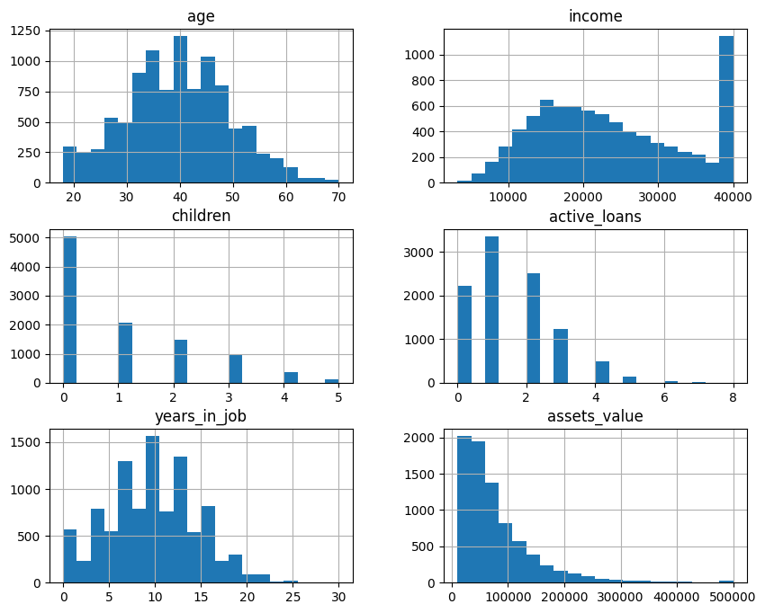

```python
data[['age','income','children','active_loans','years_in_job','assets_value']].hist(bins=20, figsize=(10, 8))
plt.show()
```

The histograms reveal the distributions of six key variables:

- Age: Symmetrical distribution, resembling normality, with most clients aged 30-50.
- Income: Right-skewed, indicating most customers have lower incomes, with potential outliers at higher values.
- Children: Majority have 0-1 child, with fewer observations as the number of children increases.
- Active Loans: Right-skewed, as most clients have 0-2 active loans, with higher values being rare.
- Years in Job: Roughly symmetrical, suggesting a near-normal distribution, with most people employed for 6-13 years.
- Assets Value: Strong right skew, showing that most clients own assets of relatively low value.

Potential normal distributions: `age` and `years_in_job`, while other variables exhibit skewness.

```python
# Shapiro-Wilk test
sampleA = np.random.choice(data["age"], size=5000, replace=False)
sampleY = np.random.choice(data["years_in_job"], size=5000, replace=False)
statA, pA = shapiro(sampleA)
statY, pY = shapiro(sampleY)

# D'Agostino's K-squared test
stat1, p1 = normaltest(data["age"])
stat2, p2 = normaltest(data["years_in_job"])


print("Shapiro-Wilk Test for age: p=%e" % (pA))
print("Shapiro-Wilk Test for years_in_job: p=%e" % (pY))
print("D'Agostino's K-squared Test age: p=%.10e" % (p1))
print("D'Agostino's K-squared Test years_in_job: p=%.10e" % (p2))
```

```
Shapiro-Wilk Test for age: p=1.410664e-11
Shapiro-Wilk Test for years_in_job: p=2.664127e-19
D'Agostino's K-squared Test age: p=1.2597930844e-09
D'Agostino's K-squared Test years_in_job: p=1.6094094165e-14
```

We selected 5,000 random observations. The Shapiro-Wilk test returned p-values significantly lower than 0.05, leading to the rejection of the null hypothesis, which assumes a normal distribution. Similarly, the D'Agostino's K-squared test also produced very low p-values, confirming deviations from normality. However, given the sensitivity of these tests to large samples, we will further verify normality using a Q-Q plot.

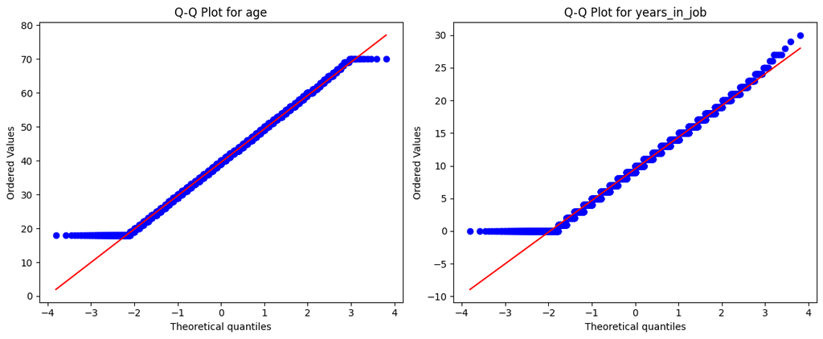

```python
fig, axes = plt.subplots(1, 2, figsize=(12, 5))

stats.probplot(data['age'], dist="norm", plot=axes[0])
axes[0].set_title('Q-Q Plot for age')

stats.probplot(data['years_in_job'], dist="norm", plot=axes[1])
axes[1].set_title('Q-Q Plot for years_in_job')

plt.tight_layout()
plt.show()
```

The Q-Q plot for `age` suggests an approximately normal distribution, as most points align with the red line. However, deviations at the tails indicate potential non-normality. The `years_in_job` distribution also shows some alignment but deviates more at the extremes, suggesting it may not fully follow a normal distribution.

## 3. First classification model

### Build a baseline model

Let's start by building a baseline model without any transformations. We will use the Random Forest Classifier to evaluate the initial performance. After obtaining the results, we will explore different techniques to improve the model.

```python
X = data.drop('credit_risk', axis=1)
y = data['credit_risk']

X_train, X_test, y_train, y_test = train_test_split(
    X, y, test_size=0.2, random_state=42, stratify=y
)

rf = RandomForestClassifier(n_estimators=100, random_state=42)
rf.fit(X_train, y_train)

y_pred = rf.predict(X_test)
y_pred_proba = rf.predict_proba(X_test)[:, 1]

print("\nClassification Report:")
print(classification_report(y_test, y_pred))

print("Confusion Matrix:")
print(confusion_matrix(y_test, y_pred))

roc_auc = roc_auc_score(y_test, y_pred_proba)
print("ROC AUC Score:", roc_auc)

accuracy = accuracy_score(y_test, y_pred)
print("Accuracy:", accuracy)
```

```
Classification Report:
              precision    recall  f1-score   support

           0       0.99      1.00      0.99      1935
           1       1.00      0.65      0.79        65

    accuracy                           0.99      2000
   macro avg       0.99      0.82      0.89      2000
weighted avg       0.99      0.99      0.99      2000

Confusion Matrix:
[[1935    0]
 [  23   42]]
ROC AUC Score: 0.870494931425164
Accuracy: 0.9885
```

The model achieved an accuracy of 0.9885, which seems excellent at first glance. However, the confusion matrix reveals a significant class imbalance. Relying solely on accuracy is misleading, so we must analyze precision, recall, and F1-score. The F1-score is 0.89, which is good, but there is room for improvement. The recall for class 1 (high risk) is only 0.65, meaning the model misclassifies many high-risk clients as low-risk. This is critical, as incorrectly approving credit for non-creditworthy individuals could be risky for the bank. We need to improve recall while maintaining a good balance with precision.

The visualization of confusion matrix:

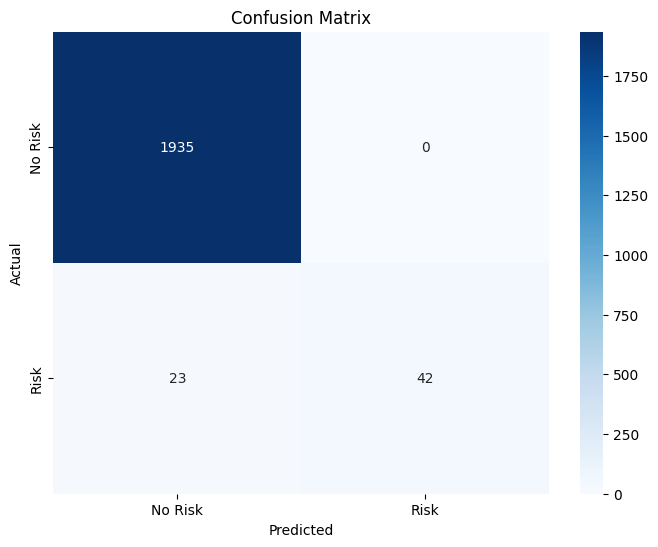

```python
plt.figure(figsize=(8, 6))
sns.heatmap(confusion_matrix(y_test, y_pred), annot=True, fmt='d', cmap='Blues', xticklabels=['No Risk', 'Risk'], yticklabels=['No Risk', 'Risk'])
plt.xlabel('Predicted')
plt.ylabel('Actual')
plt.title('Confusion Matrix')
plt.show()
```

### Class imbalance

```python
data['credit_risk'].value_counts()
```

```
credit_risk
0    9675
1     325
Name: count, dtype: int64
```

The dataset is highly imbalanced, with 9,675 samples of class 0 (low risk) and only 325 samples of class 1 (high risk).

## 4. Anomalies

### Delete the anomalies from the data

The data contains some anomalies, such as individuals who have been employed since an age younger than 14. Therefore, we need to remove these observations from the dataset.

```python
data_clean_anomalies = data.drop(data[data["age"] - data["years_in_job"] < 14].index)
len(data_clean_anomalies)
```

```
9313
```

687 rows were removed from the dataset. We will use the dataset without anomalies for further analysys.

### Classification model applied to the data excluding anomalies

Now, we build a random forest model once more using the data without anomalies.

```python
X = data_clean_anomalies.drop('credit_risk', axis=1)
y = data_clean_anomalies['credit_risk']

X_train, X_test, y_train, y_test = train_test_split(
    X, y, test_size=0.2, random_state=42, stratify=y
)

rf = RandomForestClassifier(n_estimators=100, random_state=42)
rf.fit(X_train, y_train)

y_pred = rf.predict(X_test)
y_pred_proba = rf.predict_proba(X_test)[:, 1]

print("\nClassification Report:")
print(classification_report(y_test, y_pred))

print("Confusion Matrix:")
print(confusion_matrix(y_test, y_pred))

roc_auc = roc_auc_score(y_test, y_pred_proba)
print("ROC AUC Score:", roc_auc)

accuracy = accuracy_score(y_test, y_pred)
print("Accuracy:", accuracy)
```

```
Classification Report:
              precision    recall  f1-score   support

           0       0.98      1.00      0.99      1801
           1       1.00      0.50      0.67        62

    accuracy                           0.98      1863
   macro avg       0.99      0.75      0.83      1863
weighted avg       0.98      0.98      0.98      1863

Confusion Matrix:
[[1801    0]
 [  31   31]]
ROC AUC Score: 0.886908706632516
Accuracy: 0.9833601717659689
```

The accuracy is 0.9834, slightly lower than in the previous model. However, the more concerning issue is the recall for class 1, which dropped to 0.50, meaning the model misses half of the high-risk clients. The F1-score also decreased to 0.83 from 0.89. This decline may be due to the reduced number of class 1 samples after removing anomalies, making it even harder for the model to correctly identify high-risk cases.

The visualization of confusion matrix:

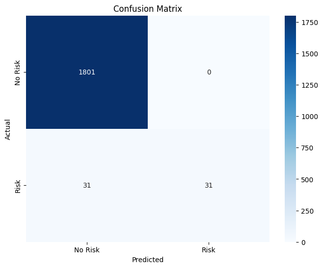

```python
plt.figure(figsize=(8, 6))
sns.heatmap(confusion_matrix(y_test, y_pred), annot=True, fmt='d', cmap='Blues', xticklabels=['No Risk', 'Risk'], yticklabels=['No Risk', 'Risk'])
plt.xlabel('Predicted')
plt.ylabel('Actual')
plt.title('Confusion Matrix')
plt.show()
```

## 5. One-Hot Encoding

### Perform One-Hot Encoding

```python
data_one_hot = data_clean_anomalies.copy(deep=True)
```

```python
children_dum = pd.get_dummies(data_one_hot["children"], prefix="children").astype(int)
data_one_hot = pd.concat([data_one_hot.drop("children", axis=1), children_dum], axis=1)

employment_dum = pd.get_dummies(data_one_hot["employment_type"], prefix="employment_type").astype(int)
data_one_hot = pd.concat([data_one_hot.drop("employment_type", axis=1), employment_dum], axis=1)

education_dum = pd.get_dummies(data_one_hot["education"], prefix="education").astype(int)
data_one_hot = pd.concat([data_one_hot.drop("education", axis=1), education_dum], axis=1)

city_dum = pd.get_dummies(data_one_hot["city"], prefix="city").astype(int)
data_one_hot = pd.concat([data_one_hot.drop("city", axis=1), city_dum], axis=1)

marital_status_dum = pd.get_dummies(data_one_hot["marital_status"], prefix="marital_status").astype(int)
data_one_hot = pd.concat([data_one_hot.drop("marital_status", axis=1), marital_status_dum], axis=1)
```

This code performs one-hot encoding on categorical variables (`children`, `employment_type`, `education`, `city`, `marital_status`).

### Build Random Forest Classifier on One Hot Encoded Data

```python
X = data_one_hot.drop('credit_risk', axis=1)
y = data_one_hot['credit_risk']

X_train, X_test, y_train, y_test = train_test_split(
    X, y, test_size=0.2, random_state=42, stratify=y
)

rf = RandomForestClassifier(n_estimators=100, random_state=42)
rf.fit(X_train, y_train)

y_pred = rf.predict(X_test)
y_pred_proba = rf.predict_proba(X_test)[:, 1]

print("\nClassification Report:")
print(classification_report(y_test, y_pred))

print("Confusion Matrix:")
print(confusion_matrix(y_test, y_pred))

roc_auc = roc_auc_score(y_test, y_pred_proba)
print("ROC AUC Score:", roc_auc)

accuracy = accuracy_score(y_test, y_pred)
print("Accuracy:", accuracy)
```

```
Classification Report:
              precision    recall  f1-score   support

           0       0.98      1.00      0.99      1801
           1       1.00      0.50      0.67        62

    accuracy                           0.98      1863
   macro avg       0.99      0.75      0.83      1863
weighted avg       0.98      0.98      0.98      1863

Confusion Matrix:
[[1801    0]
 [  31   31]]
ROC AUC Score: 0.853284913399366
Accuracy: 0.9833601717659689
```

Random forest on one-hot encoded data showed the same results as the previous model built on label-encoded data. This suggests that the model handles categorical variables well regardless of encoding type. The similarity in results could be due to the tree-based nature of random forests, which can effectively split on categorical values even when label encoded.

## 6. Outliers

Here we check the outliers in the dataset for specific numerical columns using the Interquartile Range (IQR) method.

```python
columns_to_check = ['age', 'income', 'active_loans', 'years_in_job', 'assets_value']

outliers = {}
for col in columns_to_check:
    Q1 = data_one_hot[col].quantile(0.25)
    Q3 = data_one_hot[col].quantile(0.75)
    IQR = Q3 - Q1
    lower_bound = Q1 - 1.5 * IQR
    upper_bound = Q3 + 1.5 * IQR
    outliers[col] = data_one_hot[(data_one_hot[col] < lower_bound) | (data_one_hot[col] > upper_bound)][col]

outliers_summary = {col: len(outliers[col]) for col in outliers}
outliers_summary
```

```
{'age': 38,
 'income': 0,
 'active_loans': 628,
 'years_in_job': 40,
 'assets_value': 442}
```

The IQR method indicated that `active_loans` and `assets_value` have the highest number of outliers, while `income` has none.

The visualization of the outliers:

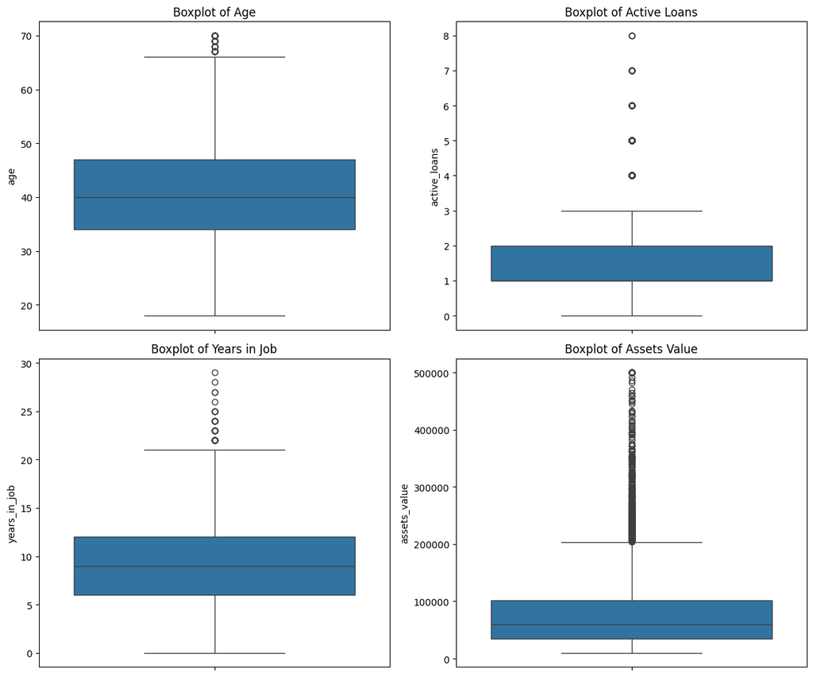

```python
fig, axes = plt.subplots(2, 2, figsize=(12, 10))

columns_to_plot = ['age', 'active_loans', 'years_in_job', 'assets_value']
titles = ['Age', 'Active Loans', 'Years in Job', 'Assets Value']

for ax, col, title in zip(axes.flatten(), columns_to_plot, titles):
    sns.boxplot(y=data_one_hot[col], ax=ax)
    ax.set_title(f'Boxplot of {title}')

plt.tight_layout()
plt.show()
```

## 7. Impute missing values

### Regression-based models for imputing

We could use regression-based models to impute missing values. However, let's first check the correlation between the variables.

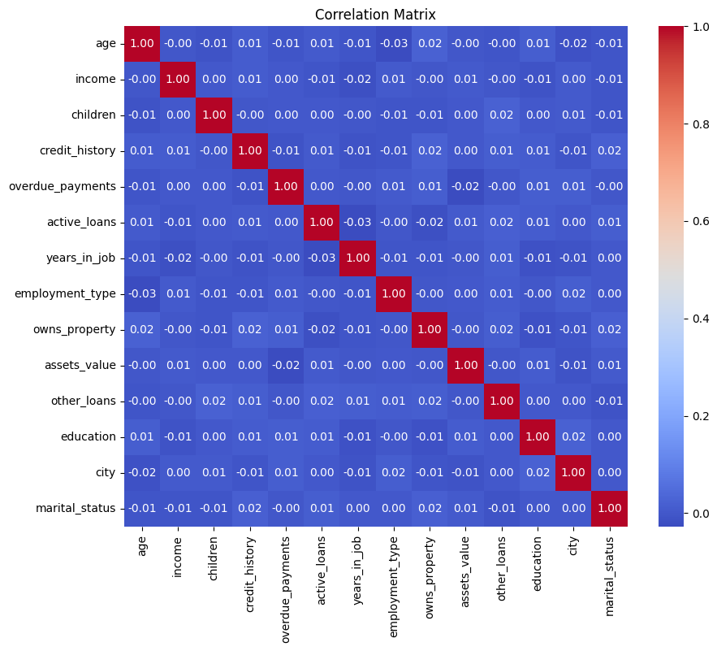

```python
corr_matrix = data.drop('credit_risk', axis=1).corr()

plt.figure(figsize=(10, 8))
sns.heatmap(corr_matrix, annot=True, cmap='coolwarm', fmt=".2f")
plt.title("Correlation Matrix")
plt.show()
```

As observed, the variables do not exhibit any strong correlation with each other. This indicates that using a regression-based model may not be a suitable approach in this case.

### KNN Imputation

K-Nearest Neighbors (KNN) Imputation works well even if variables are not strongly correlated, as it relies on similarity between data points rather than explicit relationships. Let's implement a KNN imputation model and evaluate its effectiveness in this scenario.

```python
knn_imputer = KNNImputer(n_neighbors=5)
data_imputed = pd.DataFrame(knn_imputer.fit_transform(data_clean_anomalies), columns=data_clean_anomalies.columns)
```

```python
missing_value_count = data_clean_anomalies.isnull().any(axis=1).sum()
missing_value_count
```

```
6247
```

We can note that after removing the anomalies, the number of rows with at least one missing value decreased to 6247.

```python
data_imputed.isna().sum()
```

```
age                 0
income              0
children            0
credit_history      0
overdue_payments    0
active_loans        0
years_in_job        0
employment_type     0
owns_property       0
assets_value        0
other_loans         0
education           0
city                0
marital_status      0
credit_risk         0
dtype: int64
```

The dataset now contains no missing values.

### Build Random Forest Classifier using the dataset with imputed missing values

```python
X = data_imputed.drop('credit_risk', axis=1)
y = data_imputed['credit_risk']

X_train, X_test, y_train, y_test = train_test_split(
    X, y, test_size=0.2, random_state=42, stratify=y
)

rf = RandomForestClassifier(n_estimators=100, random_state=42)
rf.fit(X_train, y_train)

y_pred = rf.predict(X_test)
y_pred_proba = rf.predict_proba(X_test)[:, 1]

print("\nClassification Report:")
print(classification_report(y_test, y_pred))

print("Confusion Matrix:")
print(confusion_matrix(y_test, y_pred))

roc_auc = roc_auc_score(y_test, y_pred_proba)
print("ROC AUC Score:", roc_auc)

accuracy = accuracy_score(y_test, y_pred)
print("Accuracy:", accuracy)
```

```
Classification Report:
              precision    recall  f1-score   support

         0.0       0.98      1.00      0.99      1801
         1.0       1.00      0.50      0.67        62

    accuracy                           0.98      1863
   macro avg       0.99      0.75      0.83      1863
weighted avg       0.98      0.98      0.98      1863

Confusion Matrix:
[[1801    0]
 [  31   31]]
ROC AUC Score: 0.8377827730114094
Accuracy: 0.9833601717659689
```

## 8. Oversampling minority class

Since the dataset has an imbalanced class distribution, we will use SMOTE (Synthetic Minority Oversampling Technique) to oversample the minority class and achieve a balanced dataset.

### SMOTE

```python
X = data_imputed.drop('credit_risk', axis=1)
y = data_imputed['credit_risk']

X_train, X_test, y_train, y_test = train_test_split(
    X, y, test_size=0.2, random_state=42, stratify=y
)

print("Original training set class distribution:")
print(y_train.value_counts())

smote = SMOTE(random_state=42)
X_train_sm, y_train_sm = smote.fit_resample(X_train, y_train)

print("\nResampled training set class distribution:")
print(pd.Series(y_train_sm).value_counts())
```

```
Original training set class distribution:
credit_risk
0.0    7203
1.0     247
Name: count, dtype: int64

Resampled training set class distribution:
credit_risk
0.0    7203
1.0    7203
Name: count, dtype: int64
```

The dataset had a significant class imbalance, with the minority class (1) underrepresented. Using SMOTE, the minority class was oversampled to match the majority class (0), resulting in a balanced training set with 7,203 samples for each class.

### Build Random Forest Classifier using the dataset with balanced data

```python
rf = RandomForestClassifier(n_estimators=100, random_state=42)
rf.fit(X_train_sm, y_train_sm)

y_pred = rf.predict(X_test)
y_pred_proba = rf.predict_proba(X_test)[:, 1]

print("\nClassification Report:")
print(classification_report(y_test, y_pred))

print("Confusion Matrix:")
print(confusion_matrix(y_test, y_pred))

roc_auc = roc_auc_score(y_test, y_pred_proba)
print("ROC AUC Score:", roc_auc)

accuracy = accuracy_score(y_test, y_pred)
print("Accuracy:", accuracy)
```

```
Classification Report:
              precision    recall  f1-score   support

         0.0       0.98      1.00      0.99      1801
         1.0       1.00      0.47      0.64        62

    accuracy                           0.98      1863
   macro avg       0.99      0.73      0.81      1863
weighted avg       0.98      0.98      0.98      1863

Confusion Matrix:
[[1801    0]
 [  33   29]]
ROC AUC Score: 0.8490175708835593
Accuracy: 0.9822866344605475
```

## 9. CatBoost Classifier

As our data has large number of categorical columns, we can use CatBoostClassifier which can handle categorical columns without special preprocessing.

### Preparing data

Here we are reading the dataset once more, deleting anomalies and converting currency columns to float.

```python
data_catboost = pd.read_csv("/Users/petromelnyk/Desktop/projects/bank_proj/bank_data.csv", index_col = 0)
data_catboost = data_catboost.drop(columns=['support_indicator '])
data_catboost = data_catboost.drop(data_catboost[data_catboost["age"] - data_catboost["years_in_job"] < 14].index)

data_catboost["income"] = data_catboost["income"].str.replace("złoty", "").astype(float)
data_catboost["assets_value"] = data_catboost["assets_value"].str.replace("złoty", "").astype(float)
```

For numerical features, we will use KNN Imputer as it effectively fills missing values without negatively impacting the model's performance metrics.

```python
knn_imputer = KNNImputer(n_neighbors=5)

data_catboost[['income', 'assets_value']] = knn_imputer.fit_transform(data_catboost[['income', 'assets_value']])
```

For categorical features, we will use business logic to fill missing values. This ensures that missing values are replaced with the most common (mode) value within a relevant group, preserving consistency in the dataset.

```python
data_catboost["credit_history"] = data_catboost.groupby("city")["credit_history"].transform(lambda x: x.fillna(x.mode()[0] if not x.mode().empty else "No Credit History"))
data_catboost["overdue_payments"] = data_catboost.groupby("employment_type")["overdue_payments"].transform(lambda x: x.fillna(x.mode()[0] if not x.mode().empty else "No Overdue Payments"))
data_catboost["owns_property"] = data_catboost.groupby("marital_status")["owns_property"].transform(lambda x: x.fillna(x.mode()[0] if not x.mode().empty else "Unknown"))
```

- The `credit_history` column is imputed based on the mode of each city, meaning that individuals in the same `city` will share similar credit history trends.
- The `overdue_payments` column is filled using the mode of `employment_type`, assuming that overdue payment patterns are more similar among people with the same type of employment.
- The `owns_property` column is imputed using the mode of `marital_status`, as marital status may influence property ownership trends. If no mode exists, a default category is assigned.

Ensure that there are no missing values in the dataset.

```python
data_catboost.isnull().sum().sum()
```

```
0
```

```python
data_catboost["credit_risk"].value_counts()
```

```
credit_risk
0    9004
1     309
Name: count, dtype: int64
```

Important to remember that the dataset is imbalanced, and the CatBoostClassifier is sensitive to such imbalances. Instead of using SMOTE, as in previous steps, we will use class_weights parameter to handle this issue. Class weights are used to assign higher weights to the minority class, making the model more sensitive to class 1 (high risk) predictions.

#### Building a model

Preparing the data for modeling by splitting it into features and a target variable, then dividing it into training and testing sets:

```python
X = data_catboost.drop('credit_risk', axis=1)
y = data_catboost['credit_risk']
X_train, X_test, y_train, y_test = train_test_split(X, y, test_size=0.2, random_state=42, stratify=y)
```

Mark the categorical variables for the model:

```python
cat_features = ["children", "credit_history", "overdue_payments",
                "employment_type", "owns_property", "education", "city", "marital_status"]
```

Adjust class weights dynamically based on dataset distribution:

```python
risk_weight = len(y_train) / (2 * sum(y_train))
no_risk_weight = len(y_train) / (2 * (len(y_train) - sum(y_train)))
```

- More weight for Risk (minority class)
- Less weight for No Risk

Initialize CatBoostClassifier:

```python
model = CatBoostClassifier(
    iterations=1000,
    learning_rate=0.05,
    depth=6,
    loss_function='Logloss',
    eval_metric='F1',
    cat_features=cat_features,
    class_weights={0: no_risk_weight, 1: risk_weight},
    random_seed=42,
    verbose=200
)
```

```python
model.fit(X_train, y_train, eval_set=(X_test, y_test), early_stopping_rounds=50, verbose=200)

y_pred = model.predict(X_test)

y_pred_proba = model.predict_proba(X_test)[:, 1]

print("\nClassification Report:")
print(classification_report(y_test, y_pred))

print("Confusion Matrix:")
print(confusion_matrix(y_test, y_pred))

roc_auc = roc_auc_score(y_test, y_pred_proba)
print("ROC AUC Score:", roc_auc)

accuracy = accuracy_score(y_test, y_pred)
print("Accuracy:", accuracy)
```

```
0:	learn: 0.9223106	test: 0.9516757	best: 0.9516757 (0)	total: 60.5ms	remaining: 1m
Stopped by overfitting detector  (50 iterations wait)

bestTest = 0.9825019267
bestIteration = 104

Shrink model to first 105 iterations.

Classification Report:
              precision    recall  f1-score   support

           0       1.00      1.00      1.00      1801
           1       0.94      0.97      0.95        62

    accuracy                           1.00      1863
   macro avg       0.97      0.98      0.98      1863
weighted avg       1.00      1.00      1.00      1863

Confusion Matrix:
[[1797    4]
 [   2   60]]
ROC AUC Score: 0.9828858519460515
Accuracy: 0.9967793880837359
```

- For class 1 (high risk), the recall is 0.97, meaning the model correctly identifies 97% of the high-risk clients. This is especially important, as incorrectly approving credit for non-creditworthy individuals could be risky for the bank.
- The F1-score is 97.5%, indicating a good classification abillities of the model for each class.
- The overall accuracy is 99.68%, and the ROC AUC is 0.983, both suggesting that the model discriminates very well between the classes.

The visualization of confusion matrix:

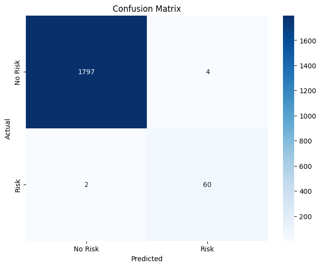

```python
plt.figure(figsize=(8, 6))
sns.heatmap(confusion_matrix(y_test, y_pred), annot=True, fmt='d', cmap='Blues', xticklabels=['No Risk', 'Risk'], yticklabels=['No Risk', 'Risk'])
plt.xlabel('Predicted')
plt.ylabel('Actual')
plt.title('Confusion Matrix')
plt.show()
```

Generally, CatBoost Classifier showed better results than Random Forest Classifier. The model is more reliable and can be used for real life scenario of credit risk classification.

Additionally let's check model's missclassified samples and shap waterfalls for better understanding of the model predictions.

```python
# Get misclassified indexes
misclassified_indexes = (y_test != y_pred)

# Extract misclassified observations
misclassified_samples = X_test[misclassified_indexes].copy()
misclassified_samples["True_Label"] = y_test[misclassified_indexes]
misclassified_samples["Predicted_Label"] = y_pred[misclassified_indexes]
misclassified_samples["Confidence_to_1"] = y_pred_proba[misclassified_indexes]
misclassified_samples
```

|  | age | income | children | credit_history | overdue_payments | active_loans | years_in_job | employment_type | owns_property | assets_value | other_loans | education | city | marital_status | True_Label | Predicted_Label | Confidence_to_1 |
| --- | --- | --- | --- | --- | --- | --- | --- | --- | --- | --- | --- | --- | --- | --- | --- | --- | --- |
| 7604 | 43 | 5923.0 | 1 dzieci | dobra historia | brak opóźnień | 2 | 0 | określona | tak | 54353.4 | 0 | podstawowe | małe | kawaler/panna | 0 | 1 | 0.775701 |
| 4327 | 49 | 5951.0 | 1 dzieci | dobra historia | brak opóźnień | 1 | 1 | samozatrudnienie | tak | 31248.0 | 1 | średnie | duże | żonaty/zamężna | 0 | 1 | 0.854683 |
| 2923 | 39 | 6068.0 | brak | dobra historia | brak opóźnień | 2 | 15 | określona | tak | 46830.0 | 0 | podstawowe | średnie | żonaty/zamężna | 0 | 1 | 0.814983 |
| 5558 | 39 | 22543.8 | 4 dzieci | dobra historia | brak opóźnień | 1 | 7 | stała | nie | 56577.0 | 0 | podstawowe | średnie | kawaler/panna | 1 | 0 | 0.064216 |
| 4442 | 45 | 38646.0 | brak | brak historii | brak opóźnień | 2 | 0 | stała | tak | 100126.8 | 0 | średnie | duże | żonaty/zamężna | 1 | 0 | 0.076481 |
| 1088 | 37 | 5046.0 | 4 dzieci | dobra historia | brak opóźnień | 0 | 16 | stała | tak | 37501.0 | 1 | podstawowe | średnie | żonaty/zamężna | 0 | 1 | 0.558408 |

```
Misclassified Sample 1: True Label = 0, Predicted Label = 1
```

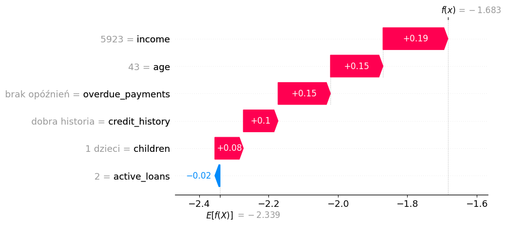

```
Misclassified Sample 2: True Label = 0, Predicted Label = 1
```

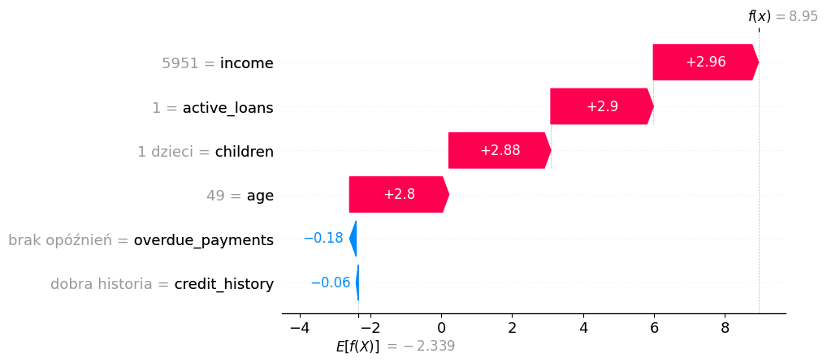

```
Misclassified Sample 3: True Label = 0, Predicted Label = 1
```

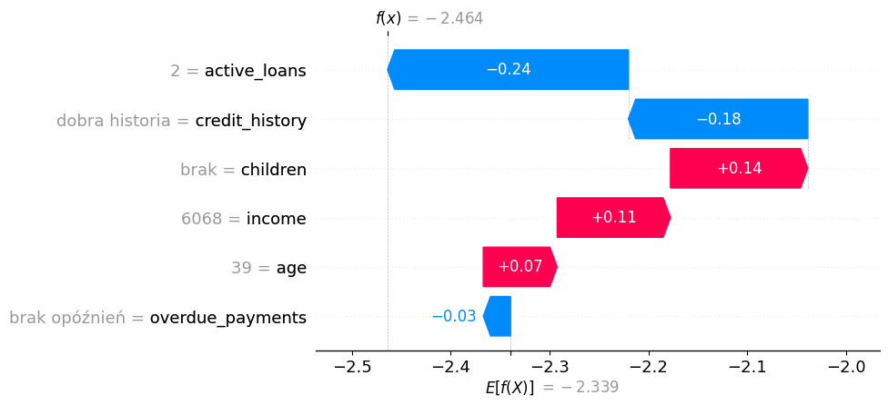

```
Misclassified Sample 4: True Label = 1, Predicted Label = 0
```

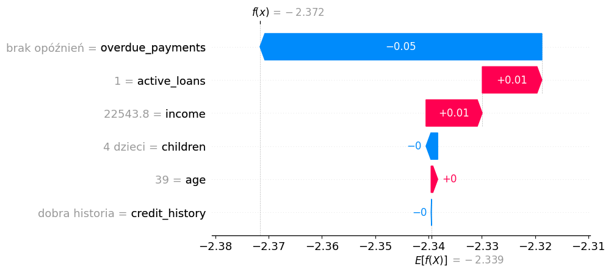

```
Misclassified Sample 5: True Label = 1, Predicted Label = 0
```

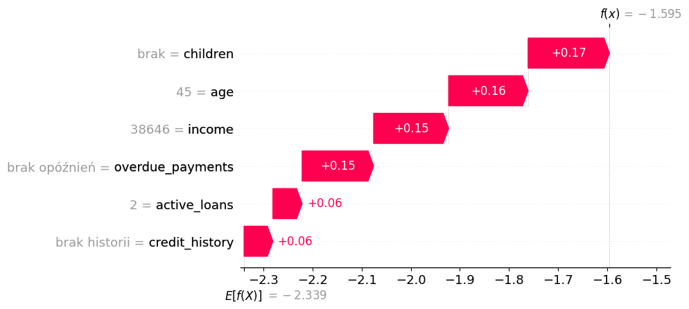

```
Misclassified Sample 6: True Label = 0, Predicted Label = 1
```

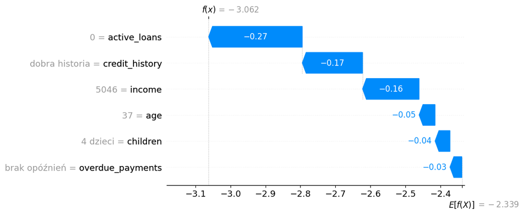

```python
# Initialize SHAP explainer
explainer = shap.TreeExplainer(model)

# Compute SHAP values for misclassified samples
shap_values = explainer.shap_values(misclassified_samples.drop(columns=["True_Label", "Predicted_Label", "Confidence_to_1"]))

# Plot SHAP waterfall for the first few misclassified samples
num_samples_to_plot = min(6, len(misclassified_samples))  # Plot up to 5 samples

for i in range(num_samples_to_plot):
    print(f"Misclassified Sample {i+1}: True Label = {misclassified_samples.iloc[i]['True_Label']}, Predicted Label = {misclassified_samples.iloc[i]['Predicted_Label']}")

    # Generate SHAP waterfall plot
    shap.waterfall_plot(shap.Explanation(values=shap_values[:, i],
                                         base_values=explainer.expected_value,
                                         data=misclassified_samples.drop(columns=["True_Label", "Predicted_Label", "Confidence_to_1"]).iloc[i],
                                         feature_names=misclassified_samples.drop(columns=["True_Label", "Predicted_Label", "Confidence_to_1"]).columns))

    plt.show()
```

## 10. Save, load and test loaded model

```python
model.save_model("catboost_credit_risk.cbm")
```

```python
from catboost import CatBoostClassifier
loaded_model = CatBoostClassifier()
loaded_model.load_model("catboost_credit_risk.cbm")
```

```
<catboost.core.CatBoostClassifier at 0x16e7989b0>
```

In addition, let's build a function which will get as arguments a dataset and a model, and will return predictions for the dataset using the model and probability for that predicted class.

```python
# Function to predict risk and get value counts
def predict_credit_risk(dataframe, model):
    """
    Predicts credit risk for given client data and returns predictions along with risk count statistics.

    Parameters:
    dataframe (pd.DataFrame): A DataFrame containing client data.
    model (CatBoostClassifier): A trained CatBoost model.

    Returns:
    pd.DataFrame: DataFrame containing predictions and probabilities to predicted class.
    """
    expected_features = [
        "age", "income", "children", "credit_history", "overdue_payments",
        "active_loans", "years_in_job", "employment_type", "owns_property",
        "assets_value", "other_loans", "education", "city", "marital_status"
    ]

    missing_features = [col for col in expected_features if col not in dataframe.columns]
    if missing_features:
        raise ValueError(f"Missing features in input data: {missing_features}")

    # Predict risk
    predictions = model.predict(dataframe)
    probabilities = model.predict_proba(dataframe)

    # Convert to human-readable labels
    risk_labels = pd.Series(predictions).map({0: "No Risk", 1: "Risk"})

    results = dataframe.copy()
    results.insert(0, 'Predicted_Class', risk_labels)
    results.insert(1, 'Probability', [probabilities[i, pred] for i, pred in enumerate(predictions)])

    return results
```

```python
sample_data = pd.DataFrame([{
    "age": 25,
    "income": 10000.0,
    "children": "0",
    "credit_history": "dobra historia",
    "overdue_payments": "opóźnień",
    "active_loans": 1,
    "years_in_job": 3,
    "employment_type": "stała",
    "owns_property": "nie",
    "assets_value": 60000,
    "other_loans": 2,
    "education": "wyższe",
    "city": "małe",
    "marital_status": "kawaler/panna"
}])


results = predict_credit_risk(sample_data, loaded_model)
results
```

|  | Predicted_Class | Probability | age | income | children | credit_history | overdue_payments | active_loans | years_in_job | employment_type | owns_property | assets_value | other_loans | education | city | marital_status |
| --- | --- | --- | --- | --- | --- | --- | --- | --- | --- | --- | --- | --- | --- | --- | --- | --- |
| 0 | Risk | 0.840956 | 25 | 10000.0 | 0 | dobra historia | opóźnień | 1 | 3 | stała | nie | 60000 | 2 | wyższe | małe | kawaler/panna |

```python
sample_data = pd.DataFrame([{
    "age": 45,
    "income": 24000.0,
    "children": "2",
    "credit_history": "dobra historia",
    "overdue_payments": "brak opóźnień",
    "active_loans": 1,
    "years_in_job": 22,
    "employment_type": "stała",
    "owns_property": "tak",
    "assets_value": 320000.0,
    "other_loans": 0,
    "education": "średnie",
    "city": "średnie",
    "marital_status": "żonaty/zamężna"
}])


results = predict_credit_risk(sample_data, loaded_model)
results
```

|  | Predicted_Class | Probability | age | income | children | credit_history | overdue_payments | active_loans | years_in_job | employment_type | owns_property | assets_value | other_loans | education | city | marital_status |
| --- | --- | --- | --- | --- | --- | --- | --- | --- | --- | --- | --- | --- | --- | --- | --- | --- |
| 0 | No Risk | 0.975674 | 45 | 24000.0 | 2 | dobra historia | brak opóźnień | 1 | 22 | stała | tak | 320000.0 | 0 | średnie | średnie | żonaty/zamężna |

Finally, we can note that our model correctly predict the potential high risk and low risk clients.

## Final Conclusion

- The project successfully developed a high-performing machine learning model for credit risk classification.
- CatBoost Classifier (CBC) emerged as the best model, outperforming Random Forest by achieving 99.67% accuracy and 0.975 F1-score.
- Despite initial challenges in identifying high-risk clients, tuning the model and using alternative techniques led to improvements.
- The final model can be trusted for real-world credit risk assessment, helping financial institutions make more informed lending decisions while minimizing default risks.